# ECP8503 Course Introductions and Environment Setup

Author

Shen Cheng

Published

May 14, 2026

# Outline

- Course introduction
- Setup course environment
  - SSH
  - Github
  - Finch Studio
  - Integrate Finch Studio with MSI

# Syllabus

## Objectives

Assuming you have taken introductory level population PK course (e.g., ECP8502):

- To provide instructions on hands-on population PK/PD analysis using NONMEM.
- To introduce population PK/PD concepts at intermediate to advanced levels.

## Course instructors:

- Shen Cheng, PhD
  - Email: cheng423@umn.edu
- Kyle Baron, PharmD, PhD
  - Email: kyleb@metrumrg.com
- Samuel Callisto, PhD
  - Email: samc@metrumrg.com
- Richard Brundage, PharmD, PhD, FCP, FISoP
  - Email: brund001@umn.edu
- Mutaz Jaber, PharmD, PhD
  - Email: mutaz.jaber@gilead.com

## Audience

- Your name
- Your Program
- Your lab

## Resources

- Github: https://github.com/UMN-ECP-PMX/ecp8503
- Minnesota Supercomputing Institute (MSI) group: `ecp8503`
- Communications:
  - Email (preferred): cheng423@umn.edu
  - Office: 717 Delaware St. SE Room 464

## Schedule and location

- 10:10 am to 12:05 pm CT weekly on Friday
- Hybrid (Attend in person is preferred):
  - In person Location:
    - 01/23/2026, 7-193/195 Weaver-Densford Hall (WDH)
    - 01/30/2026-05/08/2026, 7-145 Weaver-Densford Hall (WDH)
  - Zoom option: [https://umn.zoom.us/j/95554897171?pwd=ChzR8XR5QwwavyN8donwM7Workocz2.1&jst=2](https://www.google.com/url?q=https://umn.zoom.us/j/95554897171?pwd%3DChzR8XR5QwwavyN8donwM7Workocz2.1%26jst%3D2&sa=D&source=calendar&ust=1768017966782693&usg=AOvVaw03QWbf_vey9zf9x3cG3J4K)

## Grading

- 30% course attendance
- 30% final project (a pharmacometric analysis report)
- 30% final exam
- 10% course evaluation

## Full syllabus

<https://docs.google.com/document/d/14ttVIYZN6z524rzcIPDj6ZXysdQVEq_-/edit>

# Setup course environment

## Software for Nonlinear Mixed-Effect Modeling (NLME)

- NONMEM
- Pheonix NLME
- nlmixr
- Monolix
- ADAPT
- …

## NONMEM Ecosystem

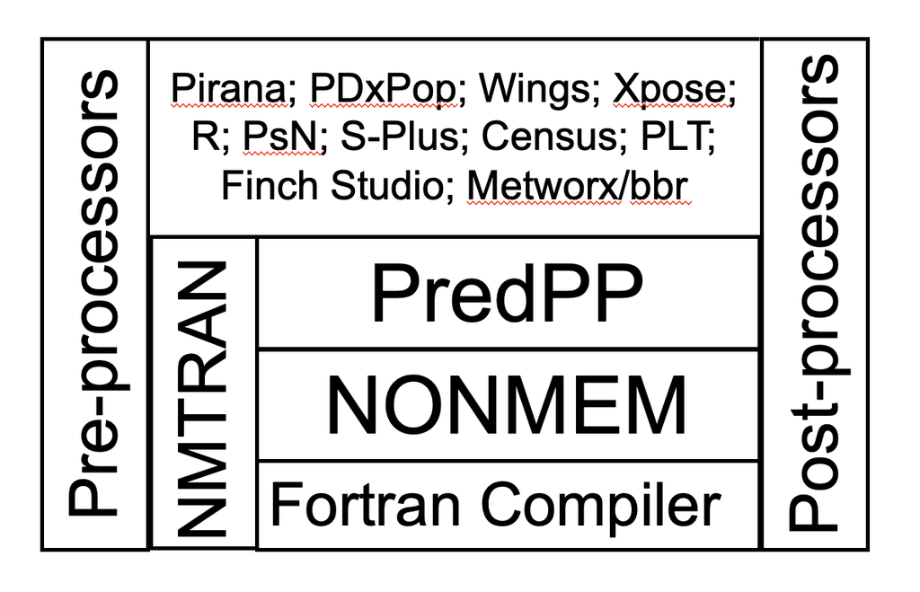

- Pre-processing utilities: text editors
- NMTRAN: parse control steam
- Fortran compiler
- NONMEM estimation engines
- PredPP: give predictions post-estimation
  - Important for PK modeling (e.g., event handling)
- Post-processing utilities: programs to handle outputs (e.g., R)
- User interfaces

## For this course…

[figure not shown]

## Course environment overview I

## SSH

- Follow the [tutorial](https://msi.umn.edu/our-resources/knowledge-base/interactive-connections-faqs/how-do-i-setup-ssh-keys) specified by MSI to setup SSH key in your local computer.
  - **Steps 1 and 2 are required**.
  - Create `~/.ssh/config` locally.
    - Mac user:
      - `cd ~/.ssh`
      - `ls`
      - `touch ~/.ssh/config`
      - Open config, copy and paste the following scripts. Replace `your.msi.username` with your X500 and save it.

      ```bash
      Host agate.msi.umn.edu
      HostName agate.msi.umn.edu
      User your.msi.username
      IdentityFile ~/.ssh/id_rsa
      ```

    - Windows user (required):
      - `cd ~/.ssh`
      - `ls`
      - `notepad ~/.ssh/config`
      - Open config, copy and paste the following scripts. Replace `your.msi.username` with your X500 and save it.

      ```bash
      Host agate.msi.umn.edu
      User your.msi.username
      IdentityFile ~/.ssh/id_rsa
      IdentitiesOnly yes
      AddKeysToAgent yes
      ```

      - In terminal, type `mv config.txt config`
      - If you do `ssh agate.msi.umn.edu`, it should ask you for passphrase now instead of password!
  - Step 3 (SSH agent activation step) is optional, and may be a little different on Windows
    - Open PowerShell on Windows:
    - Run commands:
      - `Get-Service ssh-agent`
      - `Start-Service ssh-agent`
      - `Set-Service ssh-agent -StartupType Automatic`
      - `ssh-add $env:USERPROFILE\.ssh\id_rsa`
      - `ssh-add -l`

## Github

- Add SSH key
  - Go to your github account -> Settings -> SSH and GPC keys
  - Click `New SSH Key`
  - Copy and paste in text within file `id_rsa.pub`
  - Save with a name
- **Clone** git repository (one time)
  - `git clone git@github.com:UMN-ECP-PMX/ecp8503.git`
- **Pull** updates
  - `cd /path/to/local/driectory`
  - `git pull`

## Course environment overview II

## Finch Studio

- Download Finch Studio: https://docs.finchstudio.io/installation/#installation-files
- Activate Finch Studio license
  - UMN License 2025-2026: Shared through email

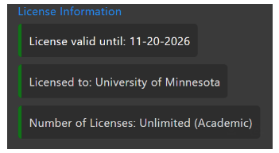

## Integrate Finch Studio with MSI

- Connect to MSI through [Open Ondemand](http://ood.msi.umn.edu/).
- Create a folder named `ecp8503/model1` in home directory: used to link local Finch Studio.
- Open Finch Studio: navigate to `CONSOLE` -> `Remote` -> `Open SSH/SFTP Remote Connection`.
  - First time set up, click `Add new connection`.
  - Non-first time, directly click connect unless a new connection is needed.

## Integrate Finch Studio with MSI: Add new connections

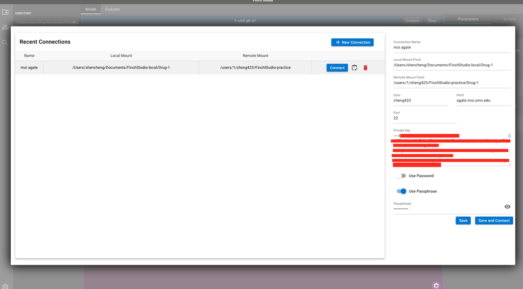

- Connection Name: any name that you prefer
  - `msi agate`
- Local Mount Point: a local directory for your project
  - `/Users/shencheng/Desktop/ecp8503`
- Remote Mount Point: a remote directory for your project
  - `/users/1/cheng423/ecp8503`
- User: MSI user name (Your X500!)
  - `cheng423` (This is mine!)
- Host: MSI host
  - `agate.msi.umn.edu`
- Port: 22 as the default SSH port. [Story](https://www.ssh.com/academy/ssh/port) behind it if you are interested…
- Private key: Copy and paste the private key in `~/.ssh/id_rsa` (NOT `~/.ssh/id_rsa.pub`).
- Passphrase is recommended. If you have configured a SSH passphrase, enabling the passphrase option as shown below and enter your passphrase at the bottom.

## Integrate Finch Studio with MSI: Save and Connect

- Two-factor authentication
- I generally select option #1, authentication through Duo Push… (Push two times, unsure why)

## Course environment overview III

## SLURM

- Slurm MSI help guide: https://msi.umn.edu/our-resources/knowledge-base/slurm-job-submission-and-scheduling
- Job submission and scheduling
- Need to have a bash script set up in advance to interact with slurm

## An example SLURM bash script

This has been provided in the github repository.

```bash
#!/bin/bash -l
#SBATCH --time=12:00:00
#SBATCH --mem=10g
#SBATCH --tmp=10g
#SBATCH --ntasks=1
#SBATCH --cpus-per-task=8
#SBATCH -L nonmem@slurmdb:1
#SBATCH --mail-type=ALL
#SBATCH --mail-user=cheng423@umn.edu
#SBATCH -p msilarge
#SBATCH --output=NONMEM.log        # Log file name

ulimit -l unlimited

module load nonmem/750-rocky8

execute mod1.ctl -nm_output=xml,ext,phi
```

## Windows user ONLY: `dos2unix`

- Windows and Linux use different “end-of-line” characters in text files.
- When you create a SLURM `.sh` script on Windows and submit it to a Linux-based HPC (e.g. MSI), the file may contain hidden Windows carriage-return characters `\r`. Linux may then misread parts of the script.
- Therefore, Windows users need one additional step to reformat `.sh` script created/edited on Windows using `dos2unix` tool before job submission:
  - Open a terminal/powershell. Run `winget install waterlan.dos2unix` (First time ONLY)
  - Close the terminal/powershell, open a new terminal/powershell:
    - `cd your/ecp8503/local/repository`
    - `dos2unix runmod.sh`
- This is not an issue for macOS users.

## Running NONMEM through Finch Studio on MSI

- Copy `./model1/data` folder from local to remote.
- Section 4 of my blog: [Use Finch Studio on MSI](https://chengshen1992.github.io/posts/FinchStudio_msi/)

# Useful links

- My blog: https://chengshen1992.github.io/posts/FinchStudio_msi/
- Finch Studio website: https://finchstudio.io/
- Finch Studio installation instructions: https://finchstudio.io/learn/setting-up-finch-studio%20copy
- PsN: https://uupharmacometrics.github.io/PsN/
- Slurm: https://msi.umn.edu/our-resources/knowledge-base/slurm-job-submission-and-scheduling
- Finch Studio Directory Structure: https://docs.finchstudio.io/installation/getting-started.html#directory-structure